# Time Series Analysis

Thomas Ott and Josh Culpepper

# An *Extremely* Brief Introduction to Time Series Analysis

In many of the models that we use, we assume *independent* observations. When we have time series data, this assumption is incorrect. A time series is a set of data with sequential observations recorded over regular time intervals. Individual observations within a time series are correlated with prior observations. Time series data are taken at widely varying intervals, such as yearly, quarterly, monthly, daily, etc.; however, you can use similar methods to analyze the data.

### When do you use time series analysis?

Any time individual observations are correlated by time. The trends, seasonality, and other factors that bear on time series data can be extracted effectively to decouple the time components of the data.

### What can you accomplish with time series analysis?

Time series allows you to examine when important events occur that may not be easily visible with other forms of analysis. Time series analysis also allows you to make predictions about systems, an important tool in natural systems with management implications.

We’re going to examine data using two popular time series analyses: An ARIMA forecast and a Fourier transform.

# Forecasting with ARIMA

**ARIMA** stands for **Autoregressive Integrated Moving Average**.

**AR** = Autoregressive parameter, denoted by **p** in the model. This value determines the autocorrelation in the time series.

**I** = Integrated parameter, denoted by **d** in the model. This value indicates the number of differences that we needed to take in order to make the time series stationary.

**MA** = Moving Average parameter, denoted by **q** in the model. This value relates the auto-correlation and lag. Different values denote auto-correlation with varying lags.

Essentially, an **ARIMA** model uses **differencing** to **detrend** data in order to make reasonable **predictions** about the future. Let’s use the following temperature data to make a prediction about the future.

First, let’s install some libraries, in case you don’t already have them:

```r
#install.packages(c("forecast","tseries", "lubridate", "tidyverse"))
library(tidyverse)
library(lubridate)
library(forecast)
library(tseries)
```

Now import the data we’ll be using. This data comes from Google Earth Engine.

```r
#import data
df <- read_csv("CENMET.csv")
str(df)
```

```
## Classes 'spec_tbl_df', 'tbl_df', 'tbl' and 'data.frame': 6939 obs. of  5 variables:
##  $ date: chr  "2000/1/1" "2000/1/2" "2000/1/3" "2000/1/4" ...
##  $ prcp: num  16.944 10.47 2.214 31.28 0.891 ...
##  $ tmin: num  271 270 272 272 268 ...
##  $ tmax: num  277 275 278 279 277 ...
##  $ elev: num  1126 1126 1126 1126 1126 ...
##  - attr(*, "spec")=
##   .. cols(
##   ..   date = col_character(),
##   ..   prcp = col_double(),
##   ..   tmin = col_double(),
##   ..   tmax = col_double(),
##   ..   elev = col_double()
##   .. )
```

The date reads as a character, so we need to change it to a date element before we can create our time series element.

```r
df$date <- ymd(df$date)
str(df)
```

```
## Classes 'spec_tbl_df', 'tbl_df', 'tbl' and 'data.frame': 6939 obs. of  5 variables:
##  $ date: Date, format: "2000-01-01" "2000-01-02" ...
##  $ prcp: num  16.944 10.47 2.214 31.28 0.891 ...
##  $ tmin: num  271 270 272 272 268 ...
##  $ tmax: num  277 275 278 279 277 ...
##  $ elev: num  1126 1126 1126 1126 1126 ...
##  - attr(*, "spec")=
##   .. cols(
##   ..   date = col_character(),
##   ..   prcp = col_double(),
##   ..   tmin = col_double(),
##   ..   tmax = col_double(),
##   ..   elev = col_double()
##   .. )
```

Looks good. Now, we can glance at the data.

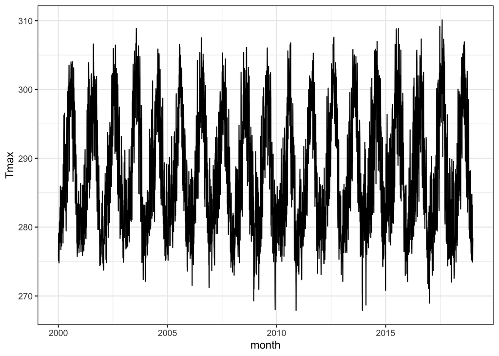

```r
ggplot(df, aes(date, tmax)) + geom_line() + scale_x_date('month') +
  ylab("Tmax") +
  xlab("") +
  theme_bw()
```

This data set gives temperature in Kelvin, which is why these numbers look so high. We could adjust that, but there’s no real point for this analysis. Besdies that, there’s a lot of data here and it can be a little difficult to maneuver with it. We’re going to cut it down to just a few years of data.

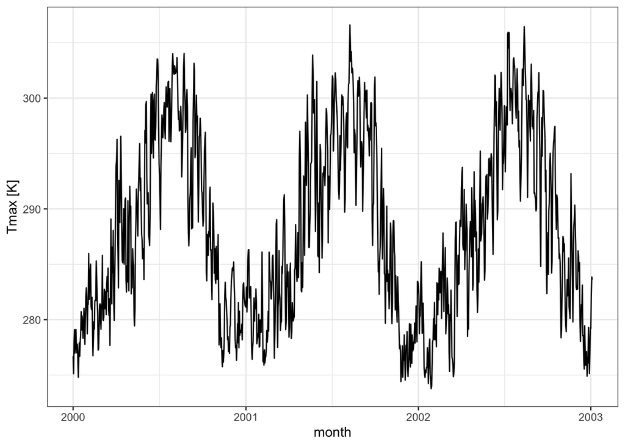

```r
df1 <- df[c(1:1100),]
ggplot(df1, aes(date, tmax)) + geom_line() + scale_x_date('month') +
  ylab("Tmax [K]") +
  xlab("") +
  theme_bw()
```

Let’s add a month and a year column for our time series analysis.

```r
#add month again for TS analysis
df1$month<- month(df1$date)
df1$year <- year(df1$date)
```

Now, let’s quickly check the range and look for any outliers. (**Note**: ARIMA assumes that there are no outliers.)

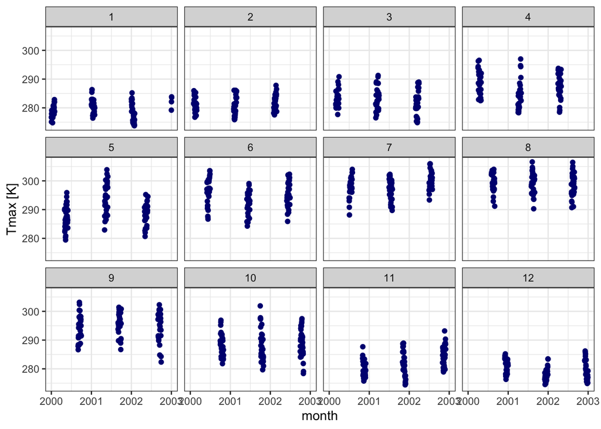

```r
#plot month over month DO to see the range and outliers -- We see some variation within months between years
ggplot(df1, aes(date, tmax)) + geom_point(color = "navyblue") +
  facet_wrap(~month) + scale_x_date('month') +
  ylab("Tmax [K]") +
  xlab("Wrap by month for all years")+
  theme_bw()
```

# Create a time series object

```r
#Create a time series object based on Tmax to pass to tsclean()
TS.Tmax <- ts(df1[,c("tmax")])
```

Within the forecast package, tsclean() takes care of any outliers and missing data, ensuring that we do not run into any issues with out time series.

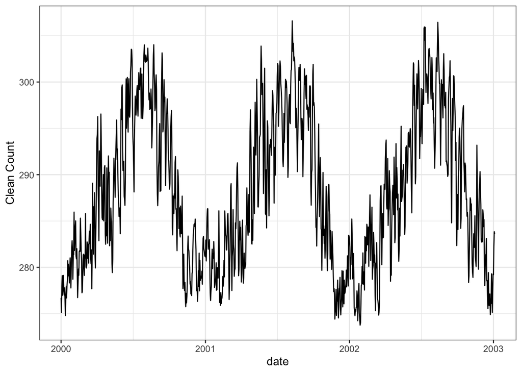

```r
#tsclean() function to ID and replace outliers and input missing values if they exist
df1$clean_count <- tsclean(TS.Tmax)

#Graph cleaned data - ignore type as scale warning
ggplot() +
  geom_line(data = df1, aes(x = date, y = clean_count)) +
  ylab('Clean Count') +
  theme_bw()
```

The data are still quite variable, so it may be useful to eliminate some of that variability. Let’s create some moving averages in order to smooth out that variability.

```r
#Get monthly and weekly moving averages (MA) and compare to cleaned daily data which
#still has a lot of variance and volatility in it.
df1$plotdata.ma7 <- ma(df1$clean_count, order=7)
df1$plotdata.ma30 <- ma(df1$clean_count, order=30)
```

Graphing original data, and weekly and monthly moving averages

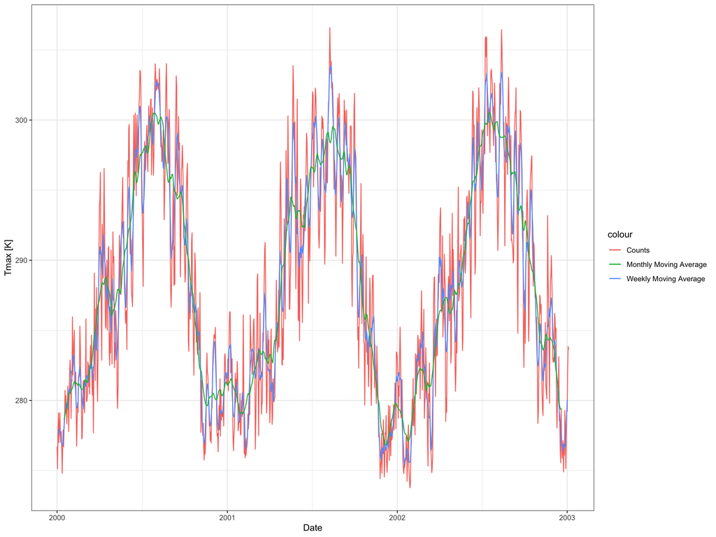

```r
ts1 <- ggplot() +
  geom_line(data = df1, aes(x = date, y = clean_count, colour = "Counts")) +
  geom_line(data = df1, aes(x = date, y = plotdata.ma7, colour = "Weekly Moving Average")) +
  geom_line(data = df1, aes(x = date, y = plotdata.ma30, colour = "Monthly Moving Average")) +
  ylab('Tmax [K]') +
  xlab('Date') +
  theme_bw()

ts1
```

We can see the highly variable daily time step in red. The slightly smoothed weekly average in blue eliminates some of that initial variability. The monthly moving average is quite smoothed and has likely removed too much from the data.